# Assignment #7

Ethan Jantz

11/20/2020

This document is made using [R Markdown](https://rmarkdown.rstudio.com/), a great tool for sharing research in a way that is readable and reproducible.

# Assignment 7

Develop two hypotheses about relationships among continuous variables.

Test each one using correlations. Test each one using bivariate regression.

Pick one of the relationships.

Choose 2 control variables and run a multivariate regression model testing the relationship including the control variables as predictors.

Describe any transformations of variables, incorporate R syntax into your document as you explain what you did and why you did it, and interpret the results.

```r
knitr::opts_chunk$set(echo = TRUE, message = FALSE, warning = FALSE) # R Markdown options
library(tidyverse)
library(tidymodels) # For building models using tidy methods
library(rmarkdown) # For accessing the functions used to display tables
library(haven) # For reading ANES2016.dta file

anes <- haven::read_dta("ANES2016.dta") %>% # Reading in the data
  zap_labels()

lm_mod <- linear_reg() %>% # Setting the type of model I want to use
  set_engine("lm")
```

Note: Haven includes information that we don’t need in this analysis and that interferes with tidymodels packages. Because of this I ran the `zap_labels()` function to remove the problematic parts of the data.

Note 2: Creating `lm_mod` in advance allows me to not repeat code that I will be using between the three regressions. The `lm_mod` object is an empty model object that I can fit data into.

# Hypotheses

**Hypothesis 1**: Respondents who feel warmer about Bill Clinton (**V161093**) will also have warmer feelings about Hillary Clinton’s candidacy (**V161086**).

**Control Variables**: The party with which the respondent is registered (**V161019**) and their gender (**V161342**)

I’ll select the variables from the full ANES dataset, filter out NA and inapplicable values, and convert the categorical variables to labeled factors.

```r
selected <- anes %>%
  select(
    # Testing Variables
    Bill = V161093,
    Hillary = V161086,
    Community_Years = V161331x,
    Income = V161361x,
    # Control Variables
    Gender = V161342,
    Party_Reg = V161019
  ) %>%
  filter(
    Bill %in% c(0:100),
    Hillary %in% c(0:100),
    Community_Years %in% c(1:40),
    Income %in% c(0:28),
    Gender %in% c(1,2),
    Party_Reg %in% c(1,2,4)
  ) %>%
  mutate(
    Gender = factor(Gender, labels = c("Male", "Female")),
    Party_Reg = factor(Party_Reg, labels = c("Dem", "Rep", "None/Ind"))
  )
```

## Hypothesis 1

My first hypothesis is that warmer feelings toward Bill Clinton are associated with similar feelings toward Hillary Clinton. The null hypothesis is that there is no association. In this test the dependent variable is feeling toward Hillary Clinton and the independent variable is feeling toward Bill Clinton.

### Correlation

I’ll run a correlation test for the data and plot it.

```r
cor.test(selected$Bill, selected$Hillary)
```

```
##
##  Pearson's product-moment correlation
##
## data:  selected$Bill and selected$Hillary
## t = 58.883, df = 1934, p-value < 2.2e-16
## alternative hypothesis: true correlation is not equal to 0
## 95 percent confidence interval:
##  0.7846621 0.8166067
## sample estimates:
##       cor
## 0.8012045
```

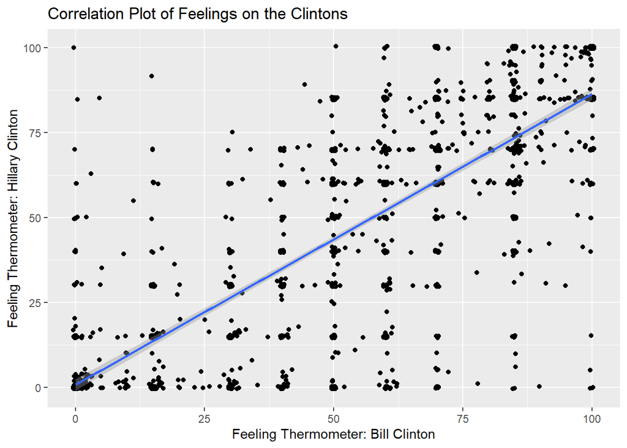

```r
selected %>%
  select(Bill, Hillary) %>%
  ggplot(aes(x = Bill, y = Hillary)) +
  geom_jitter() +
  geom_smooth(method = "lm") +
  labs(x = "Feeling Thermometer: Bill Clinton",
       y = "Feeling Thermometer: Hillary Clinton",
       title = "Correlation Plot of Feelings on the Clintons")
```

It looks like there is a strong (.8) and significant (p < .001) positive correlation between the two variables. Next I’ll explore this correlation by building a model.

### Regression

Next, I’ll run the `lm_mod` object from earlier and fit the relevant data. `tidy()` and `glance()`provide the same information that `summary()` does for `lm` objects.

```r
lm_clinton <- lm_mod %>% # Creating a linear model for the above plot
  fit(Hillary ~ Bill, data = selected)

tidy(lm_clinton) # tidy() creates a description of the model parameters
```

```
## # A tibble: 2 x 5
##   term        estimate std.error statistic p.value
##   <chr>          <dbl>     <dbl>     <dbl>   <dbl>
## 1 (Intercept)    0.875    0.873       1.00   0.316
## 2 Bill           0.854    0.0145     58.9    0
```

```r
glance(lm_clinton) # glance() creates a description of the r-squared and adjusted values for the model
```

```
## # A tibble: 1 x 12
##   r.squared adj.r.squared sigma statistic p.value    df logLik    AIC    BIC
##       <dbl>         <dbl> <dbl>     <dbl>   <dbl> <dbl>  <dbl>  <dbl>  <dbl>
## 1     0.642         0.642  21.0     3467.       0     1 -8638. 17282. 17299.
## # ... with 3 more variables: deviance <dbl>, df.residual <int>, nobs <int>
```

```r
### If I wanted to see the actual predicted values for each observation I could perform this transformation
# selected <- selected %>%
#   bind_cols(
#     predict(lm_clinton, selected)
#   )
```

The results here show that there is a significant (p < .001) relationship between respondents feelings on the Clintons. The intercept (.87) indicates that those with the coolest possible feeling toward Bill will also have cool feelings toward Hillary. For each one point increase in feeling toward Bill, the feeling toward Hillary will increase by .85 points. The r-squared value indicates that 64% of the variance in the thermometer values for Hillary Clinton are explained by the thermometer values for Bill Clinton.

## Hypothesis 2

My second hypothesis is that respondents who have lived longer in their community will have higher incomes. The null hypothesis is that there is no relationship between the two variables. In this test the dependent variable is income and the independent variable is years lived in community.

### Correlation

```r
cor.test(selected$Community_Years, selected$Income)
```

```
##
##  Pearson's product-moment correlation
##
## data:  selected$Community_Years and selected$Income
## t = -1.2205, df = 1934, p-value = 0.2224
## alternative hypothesis: true correlation is not equal to 0
## 95 percent confidence interval:
##  -0.07220293  0.01682800
## sample estimates:
##         cor
## -0.02774248
```

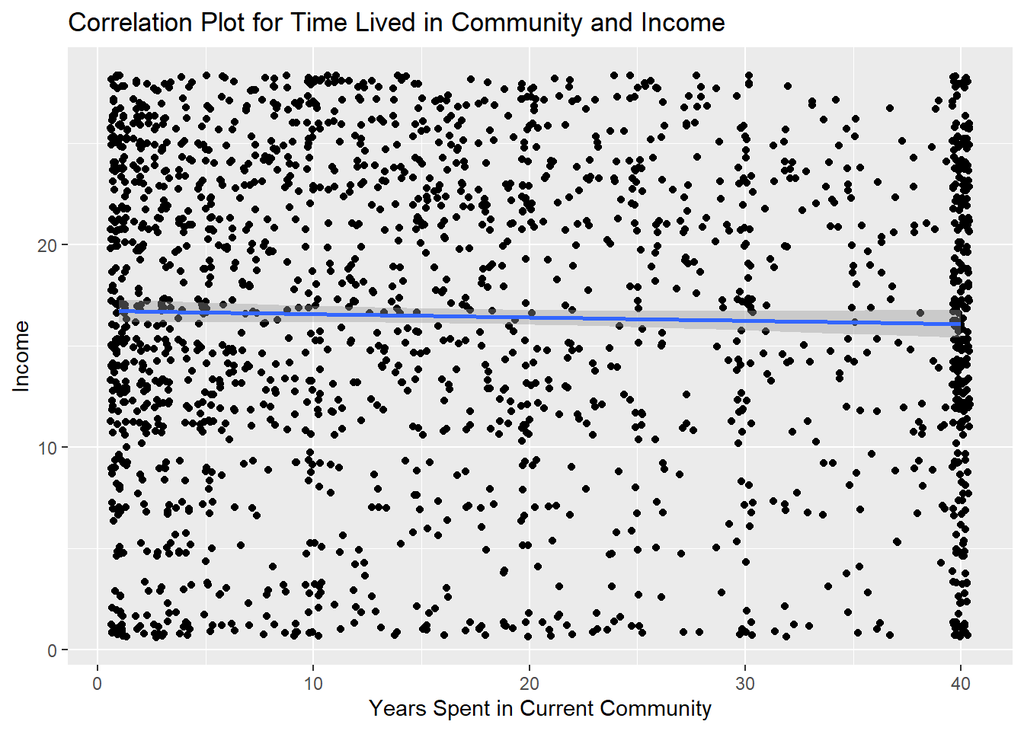

```r
selected %>%
  select(Community_Years, Income) %>%
  ggplot(aes(x = Community_Years, y = Income)) +
  geom_jitter() +
  geom_smooth(method = "lm") +
  labs(x = "Years Spent in Current Community", y = "Income",
       title = "Correlation Plot for Time Lived in Community and Income")
```

This correlation is neither strong (-.02) nor significant (p ~ .22), let’s further explore this relationship (or lackthereof) using regression.

### Regression

This is the same approach that I used for the previous regression model.

```r
lm_income <- lm_mod %>%
  fit(Income ~ Community_Years, data = selected)

tidy(lm_income)
```

```
## # A tibble: 2 x 5
##   term            estimate std.error statistic p.value
##   <chr>              <dbl>     <dbl>     <dbl>   <dbl>
## 1 (Intercept)      16.7       0.295      56.8    0
## 2 Community_Years  -0.0163    0.0134     -1.22   0.222
```

```r
glance(lm_income)
```

```
## # A tibble: 1 x 12
##   r.squared adj.r.squared sigma statistic p.value    df logLik    AIC    BIC
##       <dbl>         <dbl> <dbl>     <dbl>   <dbl> <dbl>  <dbl>  <dbl>  <dbl>
## 1  0.000770      0.000253  7.97      1.49   0.222     1 -6764. 13533. 13550.
## # ... with 3 more variables: deviance <dbl>, df.residual <int>, nobs <int>
```

These results show that there is no significant relationship (p ~ .22) between the number of years a respondent has lived in their community and their income. The resulting r-squared value is negligible (rsq < .001), meaning that years lived in the community has almost no explanatory power on a respondent’s income.

# Further Exploration of Hypothesis 1

I will further explore the hypothesis that there is a relationship between feelings toward Bill and Hillary by controlling for gender and party registration. In this test the baseline comparison is a male democrat.

```r
lm_clinton_2 <- lm_mod %>%
  fit(Hillary ~ Bill + Gender + Party_Reg, data = selected)

tidy(lm_clinton_2)
```

```
## # A tibble: 5 x 5
##   term              estimate std.error statistic   p.value
##   <chr>                <dbl>     <dbl>     <dbl>     <dbl>
## 1 (Intercept)         16.2      1.46       11.1  1.21e- 27
## 2 Bill                 0.694    0.0166     41.8  2.46e-272
## 3 GenderFemale         3.92     0.898       4.37 1.32e-  5
## 4 Party_RegRep       -20.3      1.27      -16.0  2.18e- 54
## 5 Party_RegNone/Ind  -11.8      1.20       -9.80 3.55e- 22
```

```r
glance(lm_clinton_2)
```

```
## # A tibble: 1 x 12
##   r.squared adj.r.squared sigma statistic p.value    df logLik    AIC    BIC
##       <dbl>         <dbl> <dbl>     <dbl>   <dbl> <dbl>  <dbl>  <dbl>  <dbl>
## 1     0.691         0.691  19.5     1080.       0     4 -8495. 17002. 17035.
## # ... with 3 more variables: deviance <dbl>, df.residual <int>, nobs <int>
```

Considering the r-squared value of .69, an increase from the bi-variate model, this is a better predictive model than the first version. However, there is still a 30% variance in the actual compared to the predicted values. I could probably improve this model by controlling for income (V161361x), ideology (V161126), and/or how they feel about using military force to solve international problems (V161154).